# Final Project

## Introduction

The booking process for hotel reservations is a complex system, with different factors that interact to affect the average price per room, the likelihood of the customer making special requests, and the cancellation rate. Understanding the how these factors connect to one another can help hotel managers optimize their pricing and marketing strategies to increase revenue and reduce cancellations.This leads us to our research question below.

### Research Question

```
How do different factors in the hotel booking process, such as the lead time and price interact to affect the cancellation rate?
```

The hotel industry is highly competitive, and finding ways to differentiate oneself from the competition can be challenging.

By understanding the key drivers of customer behavior and preferences, hotel managers can tailor their offerings and marketing messages to attract and retain customers.

For example, if the research finds that customers who book further in advance are more likely to cancel their bookings, hotel managers can develop early booking discounts and promotions to incentivize customers to book early.

Overall, the research question aims to shed light on the complex and dynamic nature of the hotel booking process, and provide insights that can help hotel managers improve their revenue and customer satisfaction.

## Data

This data set contains the different attributes of customers’ reservation details.

```r
hotel_data<-read.csv("Hotel Reservations.csv")
```

### Here you will find the detailed data directory:

1. Booking_ID: unique identifier of each booking
2. no_of_adults: Number of adults
3. no_of_children: Number of Children
4. no_of_weekend_nights: Number of weekend nights (Saturday or Sunday) the guest stayed or booked to stay at the hotel
5. no_of_week_nights: Number of week nights (Monday to Friday) the guest stayed or booked to stay at the hotel
6. type_of_meal_plan: Type of meal plan booked by the customer.
7. required_car_parking_space: Does the customer require a car parking space? (0 - No, 1- Yes)
8. room_type_reserved: Type of room reserved by the customer. The values are ciphered (encoded) by INN Hotels.
9. lead_time: Number of days between the date of booking and the arrival date
10. arrival_year: Year of arrival date
11. arrival_month: Month of arrival date
12. arrival_date: Date of the month
13. market_segment_type: Market segment designation.
14. repeated_guest: Is the customer a repeated guest? (0 - No, 1- Yes)
15. no_of_previous_cancellations: Number of previous bookings that were cancelled by the customer prior to the current booking
16. no_of_previous_bookings_not_cancelled: Number of previous bookings not cancelled by the customer prior to the current booking
17. avg_price_per_room: Average price per day of the reservation; prices of the rooms are dynamic. (in euros)
18. no_of_special_requests: Total number of special requests made by the customer (e.g. high floor, view from the room, etc)
19. booking_status: Flag indicating if the booking was cancelled or not.

### Data History:

According to the dataset author the data has been captured from single location/country which, due to discretionary reasons, could not be disclosed.

The population that was selected for gathering the data was the hotel’s customers and the sample was collected by them booking their stay at the hotel either online or through the reception.

## Exploratory Data Analysis

### Data Cleaning

- Check for missing values

```r
sum(is.na(hotel_data))
```

```
## [1] 0
```

- Drop rows with missing values

```r
hotel_data <- na.omit(hotel_data)
```

- Check for duplicates

```r
sum(duplicated(hotel_data))
```

```
## [1] 0
```

- Drop duplicates

```r
hotel_data <- unique(hotel_data)
```

- Rename column for consistency

```r
colnames(hotel_data)[colnames(hotel_data) == "avg_price_per_room"] <- "price"
```

### Descriptive Statistics

#### Price

Average price by status:

```
##     Canceled Not_Canceled
##    110.58997     99.93141
```

Standard Variation of price by status:

```
##     Canceled Not_Canceled
##     32.26439     35.87215
```

Interquartile range of price by status:

```
##     Canceled Not_Canceled
##        37.09        41.24
```

#### Lead Time

Average lead time by status:

```
##     Canceled Not_Canceled
##    139.21548     58.92722
```

Standard Variation of lead time by status:

```
##     Canceled Not_Canceled
##     98.94773     64.02871
```

Interquartile range of lead time by status:

```
##     Canceled Not_Canceled
##          150           76
```

#### Sample size by status:

```
##     Canceled Not_Canceled
##        11885        24390
```

Here is a quick summary of the data calculated above using the summary() function:

```
##    lead_time          price
##  Min.   :  0.00   Min.   :  0.00
##  1st Qu.: 17.00   1st Qu.: 80.30
##  Median : 57.00   Median : 99.45
##  Mean   : 85.23   Mean   :103.42
##  3rd Qu.:126.00   3rd Qu.:120.00
##  Max.   :443.00   Max.   :540.00
```

Finally we separate into new subsets the status of the booking:

```r
cancelled<- subset(hotel_data, booking_status == "Canceled")
not_cancelled<- subset(hotel_data, booking_status == "Not_Canceled")
```

### Visualization

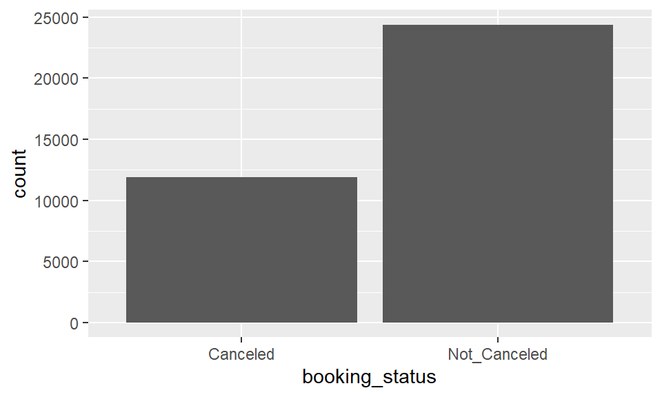

```r
ggplot(hotel_data,  aes(x = booking_status)) +
  geom_bar()
```

The bar plot shows the distribution of the booking_status variable in the hotel_data data set, with one bar representing the count of hotel bookings that were canceled and the other bar representing the count of bookings that were not canceled.

It is immediately noticeable that the count of canceled bookings is nearly half of the count of bookings that were not canceled, indicating a relatively high cancellation rate in the data set.

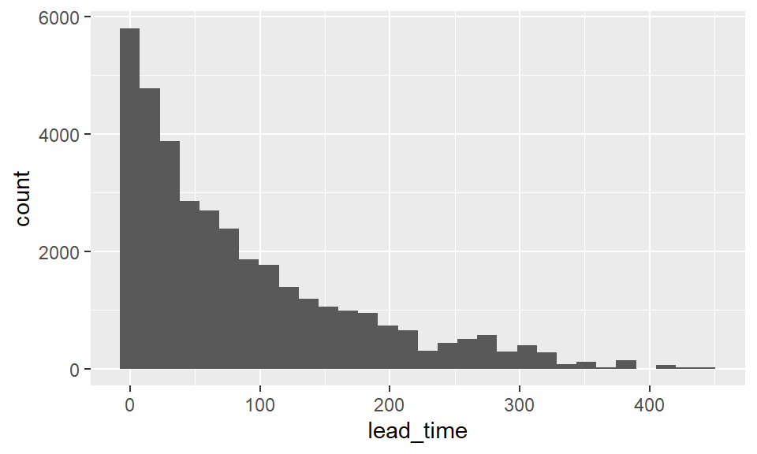

```r
ggplot(data = hotel_data, aes(x = lead_time)) +
  geom_histogram()
```

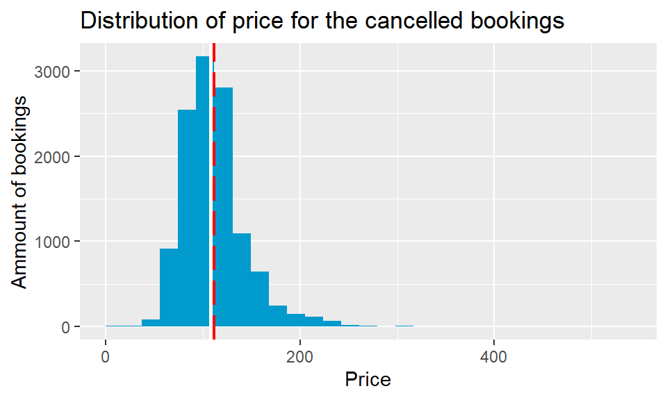

```r
ggplot(cancelled, aes(x=price)) + geom_histogram(boundary = 0, fill="deepskyblue3") +
                                      xlab("Price") + ylab("Ammount of bookings")+
                                      ggtitle("Distribution of price for the cancelled bookings")+
  geom_vline(xintercept = mean(cancelled$price), color = "red", linetype = "longdash", size = 1) +
  geom_vline(xintercept = median(cancelled$price), color = "white", size = 1)
```

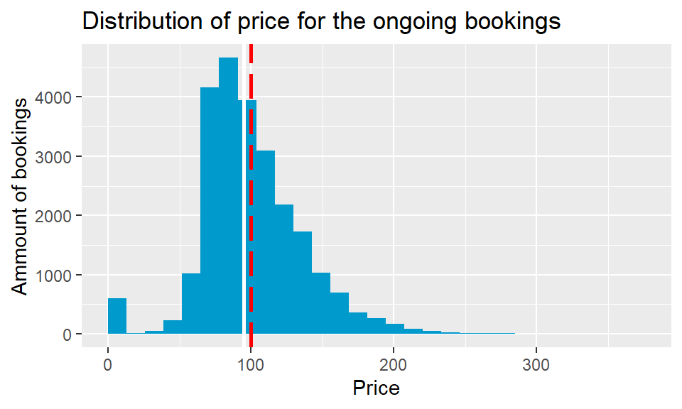

```r
ggplot(not_cancelled, aes(x=price)) + geom_histogram(boundary = 0, fill="deepskyblue3") +
                                      xlab("Price") + ylab("Ammount of bookings")+
                                      ggtitle("Distribution of price for the ongoing bookings")+
  geom_vline(xintercept = mean(not_cancelled$price), color = "red", linetype = "longdash", size = 1) +
  geom_vline(xintercept = median(not_cancelled$price), color = "white", size = 1)
```

The plot displays a scatter plot of the relationship between the lead_time variable and the price variable. Each point in the plot represents a hotel booking and its corresponding values for lead_time and price.

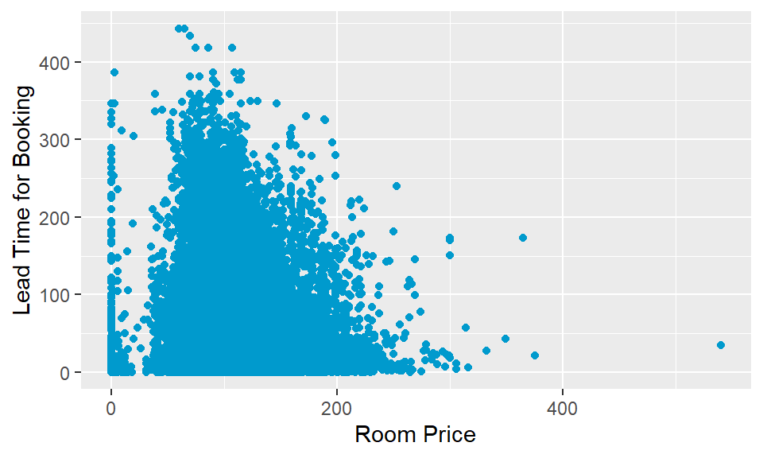

```r
ggplot(data = hotel_data, aes(x = price, y = lead_time)) +
  geom_point(colour="deepskyblue3") +
xlab("Room Price") + ylab("Lead Time for Booking")
```

This box plot shows the relationship between the booking_status variable and the price variable in the hotel_data data set. The x-axis of the plot shows the two levels of the booking_status variable, which are likely to be “Canceled” and “Not Canceled”. The y-axis of the plot represents the price of the hotel room.

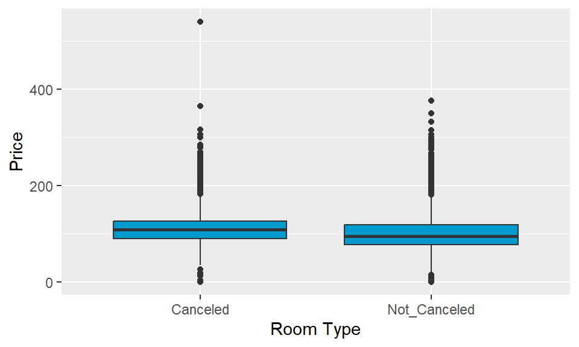

```r
ggplot(data = hotel_data, aes(x = booking_status, y = price)) +
  geom_boxplot(fill="deepskyblue3") +
  xlab("Room Type") + ylab("Price")
```

The distribution of prices for both canceled and not-canceled hotel bookings in the hotel_data data set are largely similar, with the majority of the prices clustering around the same range. However, the plot also indicates that the average price of the canceled bookings is higher than that of the not-canceled bookings. Additionally, there is an outlier in the canceled bookings group that has a much higher price than the rest of the data.

## Hypothesis and Statistical Inference

### Hypothesis

$𝐻_{0}:$The cancellation of hotel bookings is not influenced by the interplay of various factors such as lead time, and price.

$H_{A}:$The cancellation of hotel bookings is influenced by the interplay of various factors such as lead time, and price.

### Statistical Inference

#### Price

```r
means_vector<- tapply(hotel_data$price, hotel_data$booking_status, mean)
observed_diff<- as.numeric(means_vector[1]) - as.numeric(means_vector[2])
observed_diff
```

```
## [1] 10.65855
```

```r
rep<- 1000
randdiff <- c()

for (i in 1:rep){

means_shuff<-tapply(hotel_data$price, sample(hotel_data$booking_status), mean)
randdiff[i] <- as.numeric(means_shuff[1]) - as.numeric(means_shuff[2])
}

randdiff<-as.data.frame(randdiff)
colnames(randdiff)<-"diff"
```

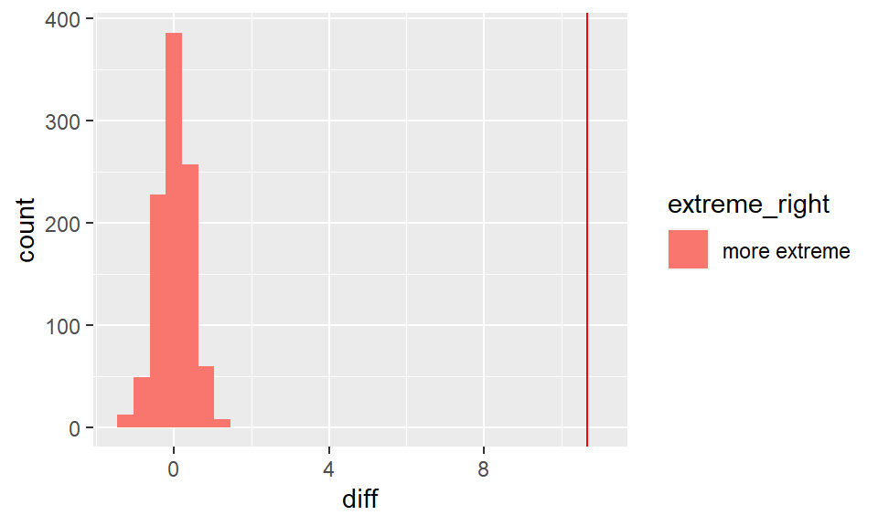

```r
randdiff$extreme_right<- ifelse((randdiff$diff<= observed_diff), "more extreme", "less extreme")

ggplot(randdiff) +
geom_histogram(aes(x = diff, fill = extreme_right)) +
geom_vline(xintercept = observed_diff, color = "red")
```

```r
p_value_simulation1<- mean((randdiff$diff<=observed_diff))
p_value_simulation1
```

```
## [1] 1
```

```r
inference(y = price,
          x =  booking_status,
          data=hotel_data,
          statistic="mean",
          type="ht",
          null = 0,
          alternative = "less",
          method="simulation",
          order = c("Not_Canceled", "Canceled"))
```

[output not shown]

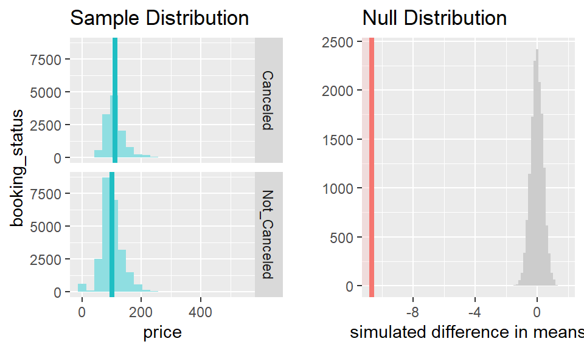

The mean price of hotel bookings that were canceled (110.59) is significantly higher than the mean price of bookings that were not canceled (99.9314). The p-value is less than 0.0001, which means that we reject the null hypothesis (H0) that there is no difference in cancellation rates between the two groups.

#### Lead Time

```r
means_vector<- tapply(hotel_data$lead_time, hotel_data$booking_status, mean)
observed_diff<-   as.numeric(means_vector[1]) - as.numeric(means_vector[2])
observed_diff
```

```
## [1] 80.28826
```

```r
rep<- 1000
randdiff <- c()

for (i in 1:rep){

means_shuff<-tapply(hotel_data$lead_time, sample(hotel_data$booking_status), mean)
randdiff[i] <- as.numeric(means_shuff[1]) - as.numeric(means_shuff[2])
}

randdiff<-as.data.frame(randdiff)
colnames(randdiff)<-"diff"
```

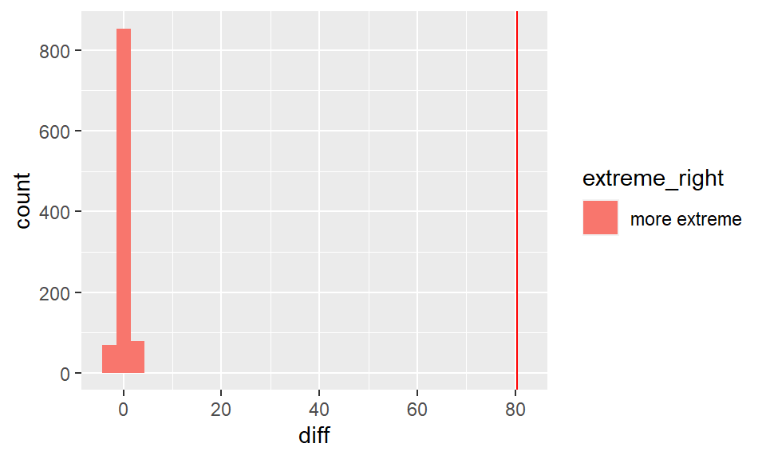

```r
randdiff$extreme_right<- ifelse((randdiff$diff<= observed_diff), "more extreme", "less extreme")

ggplot(randdiff) +
geom_histogram(aes(x = diff, fill = extreme_right)) +
geom_vline(xintercept = observed_diff, color = "red")
```

```r
p_value_simulation2<- mean((randdiff$diff<=observed_diff))
p_value_simulation2
```

```
## [1] 1
```

```r
inference(y = lead_time,
          x =  booking_status,
          data=hotel_data,
          statistic="mean",
          type="ht",
          null = 0,
          alternative = "less",
          method="simulation",
          order = c("Not_Canceled", "Canceled"))
```

[output not shown]

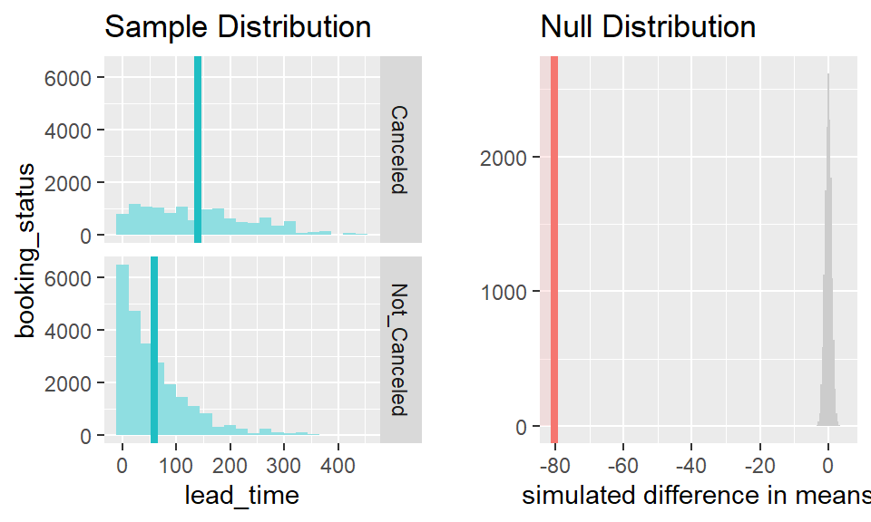

The mean lead time of hotel bookings that were canceled (139.2155) is significantly higher than the mean lead time of bookings that were not canceled (58.9272). The p-value is also less than 0.0001, which means that we reject H0 that there is no difference in cancellation rates between the two groups.

Overall, both scenarios agree and provide evidence that cancellation of hotel bookings is influenced by factors such as lead time and price. Meaning that the alternative hypothesis (HA) that cancellation is influenced by the interplay of various factors such as lead time and price is supported.

## Conclusion

What this project aimed to achieve was to find how the different factors in the hotel booking process, such as the lead time and price interact to affect the cancellation rate. I wanted to gain insight into the factors that influence customer behavior in the hotel booking process and enable hotel managers to customize their services and marketing strategies to attract and retain customers. This study aimed to unravel the intricate and ever-changing nature of the hotel booking process, and offer valuable insights that can assist hotel managers in enhancing their revenue and customer satisfaction. What we managed to achieve was exactly that, Through this data set we came to conclusion that cancellation of hotel bookings is indeed influenced by the lead time and the price of the room.

In the future it would be beneficial to add more variables into our question and hypothesis enabling us to further expand the scope of our research. Right now we were able to only look at a small part of the larger picture of the hotel booking process. It should also be noted that the variables used above, the lead_time and price were similar in essence thus in the future we would also have to add variables with more variety.

By incorporating categorical variables such as room type or location, or numerical variables such as customer ratings or room amenities, we can gain more insights into what influences customer decision-making. Additionally, studying the impact of external factors such as seasonal variations or local events can also provide valuable insights for hotel managers. All in all, our research has provided a solid foundation for further exploration of the hotel booking process and its impact on customer behavior and preferences.